# R Stats Tuto

Pierre-Alexandre

2023-10-11

# Prerequisites

*A cheat-sheet can be found [here](https://rstudio.github.io/cheatsheets/html/rmarkdown.html?_gl=1*a65iq2*_ga*MTk3MDA5NzQ0MS4xNjk3MDYyMzE3*_ga_2C0WZ1JHG0*MTY5NzA2MjMxNi4xLjEuMTY5NzA2MzAzNy4wLjAuMA..)*

## Preparation of the work space

### R & RStudio install

R & the IDE RStudio can be install from this web page : https://posit.co/download/rstudio-desktop/

1. Download then Install R
2. Download then Install RStudio

Cheat-sheet of RStudio can be found [here](https://rstudio.github.io/cheatsheets/html/rstudio-ide.html?_gl=1*1tpycou*_ga*MTk3MDA5NzQ0MS4xNjk3MDYyMzE3*_ga_2C0WZ1JHG0*MTY5NzA2MjMxNi4xLjEuMTY5NzA2MzAzNy4wLjAuMA..).

### Install package:

Packages can be install with the instruction `install.packages()` (Don’t forget the`" "`): Example for the `ggplot2` package:

```r
# Install from CRAN
install.packages("ggplot2")
```

To see all the packages which are installed use the code below:

```r
# Installed packages
installed.packages()
```

**Use a package**

After the installation of the desired package, it is neceesary to upload it in R thanks to `library` command:

```r
library("ggplot2")
library("tibble")
```

*Remark: Some library needs to compilation, for this reason each library should be called one by one.*

An other way consist to put all the library desired in a variable thank to a vector (see below), then upload it with the function `lapply` as it is showed below:

```r
x <- c("readr","tibble","tidyr","ggplot2","dplyr", "factoextra", "FactoMineR",
       "rgl", "colorspace","ggthemes","ggpubr", "readxl")
lapply(x,require,character.only = T)
```

### Work in a Working Directory

Two ways:

- `setwd("url_of_the_directory")`
- In the “File” space, More option -> select: “Set As Working Directory”

# The basic

Good resources: https://bookdown.org/ael/rexplor/

## Assignation of a variable:

In R, the variable can be assigned with two symbol `<-` OR `=`. But the first one is the most used.  
To compile a “list” of variable, it is needed to create a vector thanks to `c()` with `,` for the separation.  
Then thanks to the funtion `class` you can see the class of the variable.

```r
x <- 20
l <- c(10, 44, 89)
s <- "I am a character"
bo <- TRUE # a booleen

paste("Variable x:",x)
```

```
## [1] "Variable x: 20"
```

```r
class(x)
```

```
## [1] "numeric"
```

```r
paste("Variable l:",l)
```

```
## [1] "Variable l: 10" "Variable l: 44" "Variable l: 89"
```

```r
class(l)
```

```
## [1] "numeric"
```

```r
paste("Variable s:", s)
```

```
## [1] "Variable s: I am a character"
```

```r
class(s)
```

```
## [1] "character"
```

```r
paste("Variable s:", bo)
```

```
## [1] "Variable s: TRUE"
```

```r
class(bo)
```

```
## [1] "logical"
```

*Remarks*  
The utilization of the vector `c()` do not create a real list but a **vector**.  
For a list, it is needed to call the function `list`:

```r
li <- list(10, 44, 89)
li
```

```
## [[1]]
## [1] 10
##
## [[2]]
## [1] 44
##
## [[3]]
## [1] 89
```

```r
class(li)
```

```
## [1] "list"
```

The vector can not create missed value because all that is useless is not created. Instead of, the list permit the creation with null value:

```r
vector <- c(1, 5, NULL)
liste <- list(1, 5, "u", NULL)
vector
```

```
## [1] 1 5
```

```r
liste
```

```
## [[1]]
## [1] 1
##
## [[2]]
## [1] 5
##
## [[3]]
## [1] "u"
##
## [[4]]
## NULL
```

The command `paste()` is used to concatenate string and variable. A space is automatically include as separator. To change it, add the argument `, sep=""` with no space or other symbol. It is possible to used also `paste0`.

For any help, use the command `help()`or the symbol `?`. Example:

```r
help(class)
?ggplot2
```

To remove an object: `rm()`. At the begining of a session/project, it can be usefull to clean all the data which was kept by RSudio in its memory:

```r
rm(list = ls())
```

## Dataset Manipulation

To import Excel File, the library `readxl` is needed to be install.

### Importation of csv file

csv files are directly import as a `data.frame`. A data set can be displayed thanks to the command `View`.

```r
smp <- read.csv2("~/code/R/FUN/fichier 1/smp1.csv")
View(smp) # With upper V
```

### Some basic manipulations

To see the 6 first observations for the all variables, use the command `head()`. Use `$` to access to a variable of a data set:

```r
# Utilisation of the Iris data set, directly included in R
class(iris)
```

```
## [1] "data.frame"
```

```r
head(iris)
```

|  | Sepal.Length | Sepal.Width | Petal.Length | Petal.Width | Species |
| --- | --- | --- | --- | --- | --- |
| 1 | 5.1 | 3.5 | 1.4 | 0.2 | setosa |
| 2 | 4.9 | 3.0 | 1.4 | 0.2 | setosa |
| 3 | 4.7 | 3.2 | 1.3 | 0.2 | setosa |
| 4 | 4.6 | 3.1 | 1.5 | 0.2 | setosa |
| 5 | 5.0 | 3.6 | 1.4 | 0.2 | setosa |
| 6 | 5.4 | 3.9 | 1.7 | 0.4 | setosa |

```r
head(iris$Sepal.Length)
```

```
## [1] 5.1 4.9 4.7 4.6 5.0 5.4
```

The command `which`give the observation who respect the condition:

```r
which(iris$Species != "setosa")
```

```
##   [1]  51  52  53  54  55  56  57  58  59  60  61  62  63  64  65  66  67  68
##  [19]  69  70  71  72  73  74  75  76  77  78  79  80  81  82  83  84  85  86
##  [37]  87  88  89  90  91  92  93  94  95  96  97  98  99 100 101 102 103 104
##  [55] 105 106 107 108 109 110 111 112 113 114 115 116 117 118 119 120 121 122
##  [73] 123 124 125 126 127 128 129 130 131 132 133 134 135 136 137 138 139 140
##  [91] 141 142 143 144 145 146 147 148 149 150
```

The command `table` group and count each observation for a given variable. The command `subset(data.frame, condition, c(vector of variable))`, take the observation who respect the condition and keep only the variables asked.

```r
table(iris$Species)
```

```
##
##     setosa versicolor  virginica
##         50         50         50
```

```r
table(iris$Species != "setosa")
```

```
##
## FALSE  TRUE
##    50   100
```

```r
table(subset(iris, Species == "setosa")$Petal.Length > 1.4)
```

```
##
## FALSE  TRUE
##    24    26
```

```r
head(subset(iris, Species == "setosa", c(Sepal.Length, Petal.Length)))
```

|  | Sepal.Length | Petal.Length |
| --- | --- | --- |
| 1 | 5.1 | 1.4 |
| 2 | 4.9 | 1.4 |
| 3 | 4.7 | 1.3 |
| 4 | 4.6 | 1.5 |
| 5 | 5.0 | 1.4 |
| 6 | 5.4 | 1.7 |

### Make a *tibble* instead of *data.frame*

Upload the library `tibble`. This one allowed the creation of a *tibble* (table) that it has the same purpose than a *data.frame* but with more restriction. The *tibble* must to have the same size for each column.

```r
library(tibble)
# creation of the dataset
# m1 a list with Null values
m1<-list(1.311,1.287,1.293,1.308,1.291,1.300,1.274,1.287)
m1 <- append(m1, vector("list",5)) # append 5 element NULL contain in a list
m2<-c(1.298,1.309,1.293,1.251,1.338,1.302,1.270,1.339,1.346,1.292,1.291,1.321,1.285)
Si<-tibble("method1"=m1,"method2"=m2)
```

**Use the functional programming**

The functional programming is a paradigm of building computer program with a declarative type. In this case, the programs are constructed by applying and composing functions. In R the `tibble` library (and other *tixxx*) allow this kind programming with the following construction `variable %>% function()`. The functional is a better way to write a comprehensive workflow:

```r
# recover a list containing the values of method 1 padded with NULL values then converted to a vector, without NULL values
m1<-Si$method1 %>% unlist()
m1
```

```
## [1] 1.311 1.287 1.293 1.308 1.291 1.300 1.274 1.287
```

```r
class(m1)
```

```
## [1] "numeric"
```

### Manipulation

#### *The libraries `tidyr` & `dplyr`*

These libraries are useful to manipulate a data set.

For example, in the first table, it is supposed that each samples have been measured with the both two methods:

- sample 1 : value m1 / value m2
- sample 2 : value m1 / value m2
- …

In this case, measurements have been performed independently of the samples. So the first table does not work. Here it will be better that each value receive tag corresponding to its origin (method1 or method2). The code below propose this kind of table:

```r
library(dplyr, tidyr)
Si2<-tibble(method=c(rep("method1",8),rep("method2",13)),values=c(m1,m2))

# Let's simulate a randomized acquisition of the dataset
Si2<-Si2[sample(nrow(Si2)),] # Indexes are generated by random pick, the tibble is shuffled
head(Si2)
```

| method | values |
| --- | --- |
| method1 | 1.287 |
| method2 | 1.270 |
| method2 | 1.291 |
| method1 | 1.291 |
| method1 | 1.311 |
| method2 | 1.285 |

#### *Others manipulation trick*

```r
# Transposition without some columns
Tab.transpo <- data.frame(t(Tab.Atranspo[,-c(1:3)]))

# Put the name of the line into the 1st column (String)
Tab.transpo <- rownames_to_column(Tab.transpo, "NameColumn")

# reformat as numeric
Tab.aDeriver$variable_for_derivation <- as.numeric(Tab.aDeriver$variable_for_derivation)

## Function of the first derivative

FD2 <- data.frame(apply(Tab.aDeriver[,-1],2,function(x){ #apply fwork as a loop, apply function for each column (1 = row)(= sample)
            fd <- predict(sm.spline(Tab.aDeriver$variable_for_derivation,
                                    x),Tab.aDeriver$variable_for_derivation,2) #do the first derivative for all values
            return(fd) #returns a dataframe with values at each points
        }))
```

**Play with `tidyr` & `dplyr` libraries and functional programming**

```r
m1b<-Si2 %>% filter(method == "method1") %>% select(values) %>% unlist()
m1
```

```
## [1] 1.311 1.287 1.293 1.308 1.291 1.300 1.274 1.287
```

```r
m1b
```

```
## values1 values2 values3 values4 values5 values6 values7 values8
##   1.287   1.291   1.311   1.300   1.308   1.287   1.293   1.274
```

Cheat-sheet for more information on those libraries:

https://www.rstudio.com/wp-content/uploads/2015/02/data-wrangling-cheatsheet.pdf

## Statistics operations

A rapid view of the global statistic descriptor with the function `summary`:

```r
summary(iris)
```

```
##   Sepal.Length    Sepal.Width     Petal.Length    Petal.Width
##  Min.   :4.300   Min.   :2.000   Min.   :1.000   Min.   :0.100
##  1st Qu.:5.100   1st Qu.:2.800   1st Qu.:1.600   1st Qu.:0.300
##  Median :5.800   Median :3.000   Median :4.350   Median :1.300
##  Mean   :5.843   Mean   :3.057   Mean   :3.758   Mean   :1.199
##  3rd Qu.:6.400   3rd Qu.:3.300   3rd Qu.:5.100   3rd Qu.:1.800
##  Max.   :7.900   Max.   :4.400   Max.   :6.900   Max.   :2.500
##        Species
##  setosa    :50
##  versicolor:50
##  virginica :50
##
##
##
```

*Note: iris is a dataset which is already include in R*

### *Basic operations:*

```r
sum(iris$Sepal.Length) # Addition of all the observation in the variable
```

```
## [1] 876.5
```

```r
mean(iris$Sepal.Length) # Average
```

```
## [1] 5.843333
```

```r
sd(iris$Sepal.Length) # Standard deviation
```

```
## [1] 0.8280661
```

```r
q <- quantile(iris$Sepal.Length) # Catch all the quantiles
q
```

```
##   0%  25%  50%  75% 100%
##  4.3  5.1  5.8  6.4  7.9
```

```r
q[1]
```

```
##  0%
## 4.3
```

```r
length(iris$Sepal.Length) # Number of observation in the variable
```

```
## [1] 150
```

### *Confidence interval*

The confidence interval at 95% : $IC=\bar{x}\pm1,96*se$ with:

```r
y <- (1-0.95)/2
y
```

```
## [1] 0.025
```

```r
signif(qnorm(y),3)
```

```
## [1] -1.96
```

```r
signif(qnorm(1-y),3)
```

```
## [1] 1.96
```

*The standard error is the standard deviation of the mean of distributions and the standard deviation is for the individual distribution of a normal law.*

```r
x <- iris$Sepal.Length
x_N<-length(x)
x_sd<-sd(x)
x_mu<-mean(x)
x_se<-x_sd/sqrt(x_N)
x_ICmin<-x_mu+x_se*qnorm(0.025)
x_ICmax<-x_mu+x_se*qnorm(0.975)
paste(signif(x_ICmin,3),"<",signif(x_mu,3),"<",signif(x_ICmax,3))
```

```
## [1] "5.71 < 5.84 < 5.98"
```

The command `signif(variable, number)` print the `variable` with the `number` of significant value asked.

# Evaluation of probability law

With R, it is easy to evaluate a probability law:

- **r**mylaw(n, parameters) ==> Simulate *mylaw* with randomized variables
- **d**mylaw(x, parameters) ==> Calculate the density (or distribution) (PDF) of *mylaw*
- **p**mylaw(q, parameters) ==> Calculate the cumulative of density function (CDF) of *mylaw*
- **q**mylaw(p, parameters) ==> Calculate the quantile of mylaw

With **x** & **q** vector of values to be evaluate by *mylaw*. Can be just one value for one evaluation, several values or an interval to draw a graph for exemple. **p** is the probabilitie of *mylaw*. And **n** the number of observations to be generate.

Below the 3 mains laws:

## *Normal Law (Gauss Law)*

The Normal law is used to described continuous variables (time, temperature…) where is impossible to predict the value `k` of a variable `X` with exactitude. The reason why is the fact that the possibility to give precisely the right value is closed to 0 because the infinity of possibility. For example, it is impossible to predict that temperature in the room 401N will be exactly 20°C because there an infinity of possibility between 19.9°C and 20.1°C. However the the comportment of the variable `X` can be described thanks to the **probability density function (PDF)**. With this description, it is possible to deduce the probability in a given interval which is represented by the area under the **PDF** curve between this interval. This probability where `X` is include in `[a,b]` interval, $\mathbb{P}(X\in[a,b])$, is given by the **cumulative density function (CDF)** which is the primitive of the **PDF**:

- **PDF**: $f(x) = \frac{1}{\sigma\sqrt{2\pi}} e^{-\frac{1}{2}(\frac{x-\mu}{\sigma})^2}$
- **CDF**: $\mathbb{P}(X\in[a,b])]=\int_{a}^{b}f(x)dx$

Where $µ$ is the mean and $\sigma$ is the standard deviation which describe the normal law.

```r
my_mu<-20 # mean value of the normal law
my_sg<-sqrt(20) # std dev of the normal law
dnorm(20,mean=my_mu,sd=my_sg) # point evaluation of the density at x=20 of a normal law centered at my_mu and width sigma=my_sg
```

```
## [1] 0.08920621
```

```r
pnorm(20,mean=my_mu,sd=my_sg) # point evaluation of the CDF at q=20 of this same normal distribution
```

```
## [1] 0.5
```

```r
qnorm(0.05,mean=my_mu,sd=my_sg) # quantile of this normal distribution considering a probability p=0.05
```

```
## [1] 12.64399
```

```r
rnorm(10,mean=my_mu,sd=my_sg) # generate 10 random numbers following this normal distribution
```

```
##  [1] 21.56439 18.42741 14.28771 26.25887 14.84263 20.24649 17.23210 23.83976
##  [9] 18.48385 21.82580
```

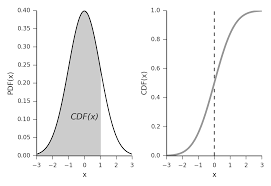

The **Cumulative Density Function** has remarkable properties:

- Always positive
- Always increasing
- y = 0 to 1

## *Binomial law*

The Binary law can be positive or negative, but in the general cases, it is only the positive which is used. This is the law which is followed by a randomization selection when there are **ONLY TWO** possibility of results: A or B, alive or died. The probability to obtained each event must be constant (but not necessary equal). The probability to obtain the A event will be $p$ and B will be $q=(1-p)$. So, with $n$ selection, the probability to obtain k event of A $\mathbb{P}(X=k)$ will follow the binomial law $B(n,p)$. The mean $\mu$ correspond to the expectation $\mathbb{E}$ (*espérance in french*) and will be give by $\mu=np$. the variance is given by $var=npq$.

```r
n<-30 # population
p<-0.1 # probability of success
dbinom(x=1,size=n,prob=p) # Probability that I win exactly 1 time in 30 plays
```

```
## [1] 0.1413039
```

```r
pbinom(q=2,size=n,prob=p) # CDF, probability to win 0,1 or 2 times in 30 plays
```

```
## [1] 0.4113512
```

```r
qbinom(p=0.5,size=n,prob=p) # Quantile of 0.5 from the binomial law
```

```
## [1] 3
```

```r
rbinom(n=10,size=n,prob=p) # Sample of size 10 from the binomial law
```

```
##  [1] 2 1 3 5 2 4 3 5 4 2
```

The formula of the binomial law is:

$$\mathbb{P}(X = k) = \binom{n}{k} p^k
(1-p)^{n-k}$$

Where $\binom{n}{k}$ is the binomial coefficient (n choose k) and can be calculate with the command `choose(n,k)` or by $\binom{n}{k} =C_n^{k}= \frac{n!}{k!(n-k)!}$

## *Poisson law*

The Poisson law is used to described the probability of a rare event in an interval of time. It is an approximation of the binomial law when the when $p$ tends to zero (very law probability) and $n$ tends to $\infty$ (a lot of repetition). This law take the parameter $\lambda = np$ and traduce the the expectation $\mathbb{E}$ and the variance (which is logical since $p\rightarrow0\Rightarrow q\rightarrow1$ in the binomial law). That’s why the Poisson law is define by $P(\lambda)$ and represent the mean of the probability where the rare event $k$ is realized.

```r
n<-30 # number of observation
m <- 20 #  Poisson law parameter
dpois(x=1, lambda =m ) #
```

```
## [1] 4.122307e-08
```

```r
ppois(q=2, lambda =m ) #
```

```
## [1] 4.55515e-07
```

```r
qpois(p=0.5, lambda =m ) #
```

```
## [1] 20
```

```r
rpois(n=n, lambda =m ) #
```

```
##  [1] 29 19 17 23 23 20 18 17 23 18 18 20 25 15 14 15 19 13 30 17 14 36 30 20 23
## [26] 20 26 13 19 20
```

The formula of the Poisson law is:
$$\mathbb{P}(X = k) = \frac{e^{-\lambda}
\lambda^k}{k!}$$

*Note: factorial calculation in R:*

```r
factorial(5)
```

```
## [1] 120
```

## Evaluation of the shape of a distrbution

It is possible to measurement of the shape of the distribution thanks to library `moment`:

```r
library("moments")
```

### Skewness: Asymetri

The Skewness moment gives some information about the symmetry of the distribution:

- **0** ==> No skewness : distribution perfectly symmetrical
- **>0** ==> The tail is on the right side of the distribution, the majority of the values is on the left compare to the mean and outlier on the right
- **<0** ==> The tail is on the left side of the distribution, the majority of the values is on the rigth compare to the mean and outlier on the left

```r
virginica <- subset(iris, Species == "virginica")
skewness(virginica$Sepal.Length, na.rm = TRUE)
```

```
## [1] 0.1144447
```

Which can be see in this graph with the mean in red:

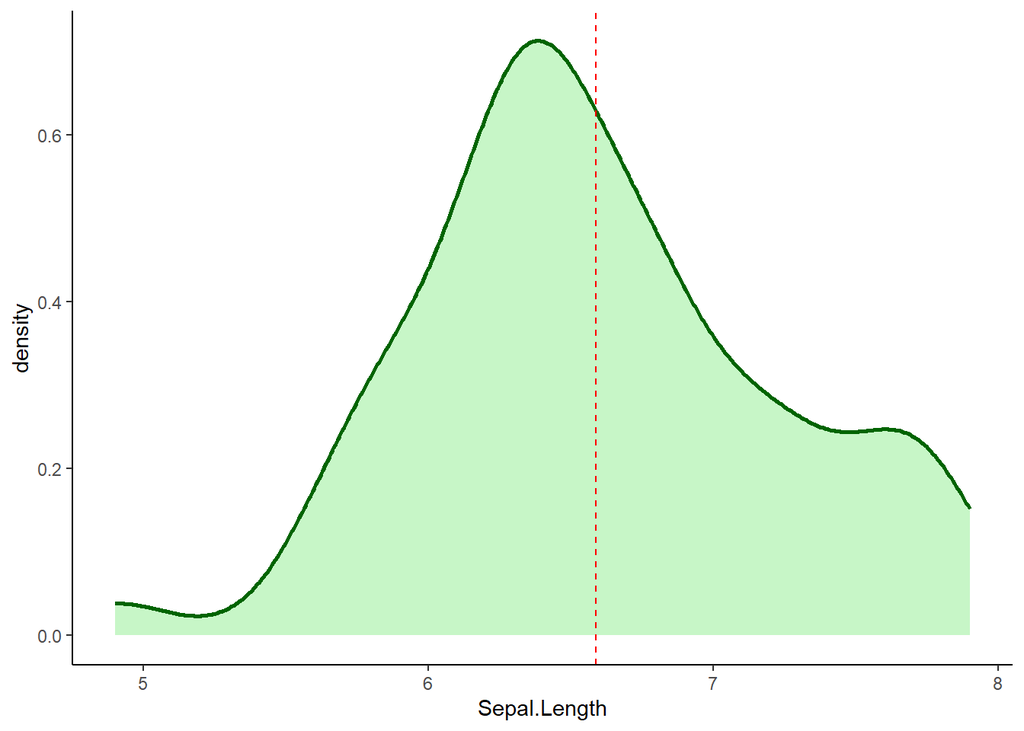

### Kurtosys: Thickness of the tail

The Kurtosys moment measure how the tails is heavy or flat.

- **=3** ==> Represent a normal distribution
- **>3** ==> TThe data distribution is eptokurtic, which means it tends to produce more outliers than the normal distribution
- **<3** ==> The data distribution is platykurtic, which means it tends to produce fewer and less extreme outliers than the normal distribution

```r
virginica <- subset(iris, Species == "virginica")
kurtosis(virginica$Sepal.Length, na.rm = TRUE)
```

```
## [1] 2.912058
```